# Data612-Project4

Vijaya Cherukuri, Habib Khan

6/29/2020

# Objective

The goal of this assignment is give you practice working with accuracy and other recommender system metrics.

Deliverables

1. As in your previous assignments, compare the accuracy of at least two recommender system algorithms against your offline data.
2. Implement support for at least one business or user experience goal such as increased serendipity, novelty, or diversity.
3. Compare and report on any change in accuracy before and after you’ve made the change in #2.
4. As part of your textual conclusion, discuss one or more additional experiments that could be performed and/or metrics that could be evaluated only if online evaluation was possible. Also, briefly propose how you would design a reasonable online evaluation environment.

# Load required libraries

```r
library(recommenderlab)  # Matrix/recommender functions
library(dplyr)           # Data manipulation
library(tidyr)           # Data manipulation
```

```r
library(ggplot2)         # Plotting
library(tictoc)          # Operation timing
```

# Dataset Information

• The dataset is a product ratings for beauty products sold on Amazon.com. The dataset was downloaded from [Kaggle.com](https://www.kaggle.com/skillsmuggler/amazon-ratings).

• Original set contains 2,023,070 observations and 4 variables - User ID, Product ID, Rating (from 1 to 5), and Time Stamp. It covers 1,210,271 users and 249,274 products. In order to make the set more manageable it has been reduced to a smaller subset.

# Subsetting Dataset

Now let’s see the process of reducing the data from the main dataset

Step 1) Import original file and select sample for project

```r
ratings <- read.csv("E:/github/MS/DATA612/Project_4/ratings_Beauty.csv")
```

Step-2) Explore

```r
head(ratings)
```

```
##           UserId  ProductId Rating  Timestamp
## 1 A39HTATAQ9V7YF 0205616461      5 1369699200
## 2 A3JM6GV9MNOF9X 0558925278      3 1355443200
## 3 A1Z513UWSAAO0F 0558925278      5 1404691200
## 4 A1WMRR494NWEWV 0733001998      4 1382572800
## 5 A3IAAVS479H7M7 0737104473      1 1274227200
## 6  AKJHHD5VEH7VG 0762451459      5 1404518400
```

```r
class(ratings$UserId); class(ratings$ProductId); class(ratings$Rating); class(ratings$Timestamp)
```

```
## [1] "factor"
```

```
## [1] "factor"
```

```
## [1] "numeric"
```

```
## [1] "integer"
```

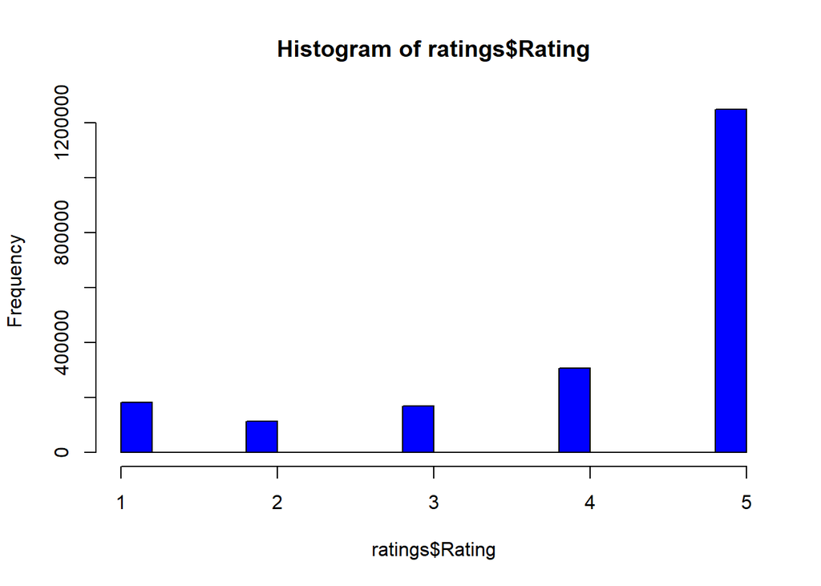

```r
hist(ratings$Rating, col = "Blue")
```

Step-3) Convert to realRatingMatrix

```r
ratingsMatrix <- sparseMatrix(as.integer(ratings$UserId), as.integer(ratings$ProductId), x = ratings$Rating)
colnames(ratingsMatrix) <- levels(ratings$ProductId)
rownames(ratingsMatrix) <- levels(ratings$UserId)
amazon <- as(ratingsMatrix, "realRatingMatrix")
```

Step-4) Explore

```r
amazon
```

```
## 1210271 x 249274 rating matrix of class 'realRatingMatrix' with 2023070 ratings.
```

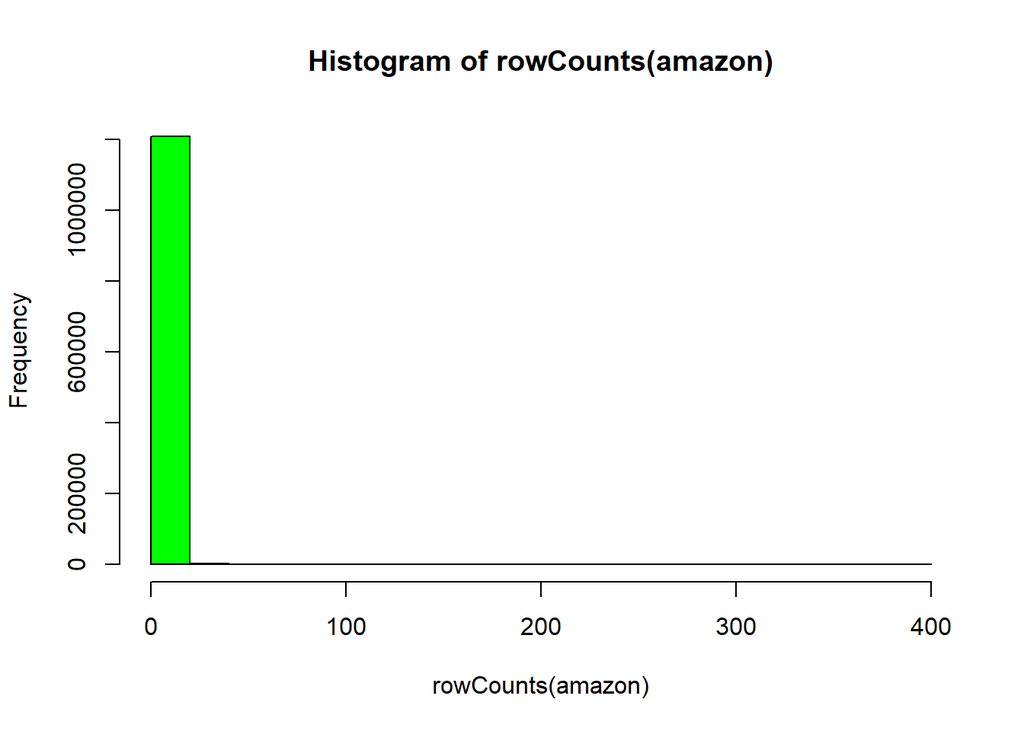

```r
hist(rowCounts(amazon), col = "Green")
```

```r
table(rowCounts(amazon))
```

```
##
##      1      2      3      4      5      6      7      8      9     10     11
## 887401 175875  64336  30285  16187   9827   6324   4260   3181   2275   1745
##     12     13     14     15     16     17     18     19     20     21     22
##   1402   1012    912    677    550    462    411    323    277    262    238
##     23     24     25     26     27     28     29     30     31     32     33
##    198    160    132    105    129     95     94     82     68     53     64
##     34     35     36     37     38     39     40     41     42     43     44
##     51     49     45     32     41     37     38     30     35     29     20
##     45     46     47     48     49     50     51     52     53     54     55
##     13     25     25     19     19     17     13     18     13     15     14
##     56     57     58     59     60     61     62     63     64     65     66
##     11     15      6      6     13      6      9     11      3     10      4
##     67     68     69     70     71     72     73     74     75     76     77
##      4      5      6      6      5      2      6      5      7      5      5
##     78     79     80     81     82     83     84     85     86     87     88
##      2      3      2      8      3      1      5      1      2      4      1
##     89     90     91     92     93     94     95     96     97     98     99
##      2      3      1      2      5      2      3      1      1      2      2
##    102    103    104    105    107    108    109    110    112    113    114
##      2      1      3      1      1      1      3      1      2      1      2
##    115    116    117    118    120    122    125    127    129    130    131
##      1      1      2      2      1      1      1      2      1      1      1
##    132    134    135    137    139    141    145    150    151    152    154
##      1      1      2      1      1      1      1      1      1      1      1
##    155    164    168    170    172    173    182    186    205    209    211
##      1      1      1      1      1      1      1      1      1      1      1
##    225    249    259    269    275    276    278    326    336    389
##      1      1      1      1      1      1      1      1      1      1
```

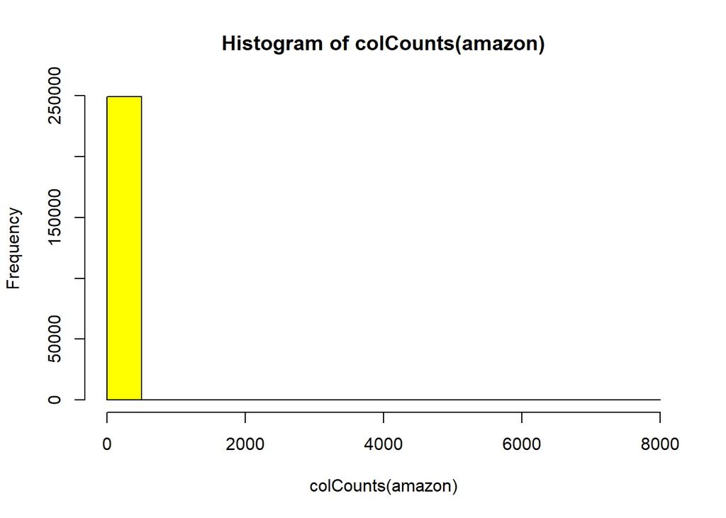

```r
hist(colCounts(amazon), col = "Yellow")
```

```r
table(colCounts(amazon))
```

```
##
##      1      2      3      4      5      6      7      8      9     10     11
## 103484  42209  22334  13902   9623   7214   5592   4404   3574   3059   2542
##     12     13     14     15     16     17     18     19     20     21     22
##   2267   2024   1657   1526   1410   1208   1096   1054    912    869    810
##     23     24     25     26     27     28     29     30     31     32     33
##    723    663    591    545    508    517    468    432    381    388    361
##     34     35     36     37     38     39     40     41     42     43     44
##    338    332    347    276    269    267    261    261    245    221    226
##     45     46     47     48     49     50     51     52     53     54     55
##    177    204    188    177    167    174    156    138    151    157    132
##     56     57     58     59     60     61     62     63     64     65     66
##    142    112    119    105    120    103    125    116    111     83     94
##     67     68     69     70     71     72     73     74     75     76     77
##     99     86     89     92     89     78     84     85     79     74     66
```

[output cut: 94 more lines]

Step-5) Select Subset 1 and Subset 2

```r
( amazonShort <- amazon[rowCounts(amazon) > 10, colCounts(amazon) > 30] )
```

```
## 10320 x 12057 rating matrix of class 'realRatingMatrix' with 111871 ratings.
```

```r
amazonShort <- amazon[ , colCounts(amazon) > 30]
amazonShort <- amazonShort[rowCounts(amazonShort) > 10, ]
amazonShort
```

```
## 3562 x 12057 rating matrix of class 'realRatingMatrix' with 68565 ratings.
```

Step-6) Check and Remove Empty Lines

```r
table(rowCounts(amazonShort))
```

```
##
##  11  12  13  14  15  16  17  18  19  20  21  22  23  24  25  26  27  28  29  30
## 598 479 335 274 264 184 163 135 118  99  84  73  73  66  50  54  26  34  36  31
##  31  32  33  34  35  36  37  38  39  40  41  42  43  44  45  46  47  48  49  50
##  31  30  22  18  17  15  11  20  15  13  11   8   7   9   8   5  10  10   4   5
##  51  52  53  54  55  56  57  58  60  61  62  63  64  65  66  67  68  69  70  71
##   8   4   7   6   4   2   3   3   1   2   4   4   1   2   4   4   2   2   1   1
##  72  73  74  75  76  77  78  79  81  85  86  90  91  93  94  95  97  98  99 100
##   1   3   2   5   2   5   1   3   3   2   1   1   2   1   1   1   1   1   1   1
## 101 103 105 110 111 112 114 116 119 126 152 185 187
##   1   1   2   1   1   1   1   1   1   1   1   1   1
```

```r
table(colCounts(amazonShort))
```

```
##
##    0    1    2    3    4    5    6    7    8    9   10   11   12   13   14   15
## 2410 2404 1849 1231  918  587  451  323  217  192  147  114   96   77   51   60
##   16   17   18   19   20   21   22   23   24   25   26   27   28   29   30   31
##   48   48   49   30   36   39   24   18   26   20   20   17   23   18   19   20
##   32   33   34   35   36   37   38   39   40   41   42   43   44   45   46   47
##   21   15   16   10   14   16   10   14    8   12   10    8    9   15   11    9
##   48   49   50   51   52   53   54   55   56   57   58   59   60   61   62   63
##    9   15   13    5    4    6   10    4    9   13   11    5    6   12    6    6
##   64   65   66   68   69   70   71   72   73   74   75   76   77   78   79   80
##    5    8    4    7    2    6    2    6    5    3    8    4    4    2    4    6
##   81   82   83   84   85   86   87   88   89   90   91   92   93   95   96   98
##    4    7    6    5    2    4    1    4    1    1    4    1    2    1    1    1
##   99  102  103  105  106  107  112  116  122  136  141  143  146  147  148  160
##    1    1    1    2    2    1    1    1    1    1    1    1    1    1    1    1
##  164  167  174  177
##    1    1    1    1
```

```r
( amazonShort <- amazonShort[ , colCounts(amazonShort) != 0] )
```

```
## 3562 x 9647 rating matrix of class 'realRatingMatrix' with 68565 ratings.
```

Step-7) Convert to data frame and save as CSV file

```r
df <- as.data.frame(as.matrix(amazonShort@data))
df$UserId <- rownames(df)
df <- df %>% gather(key = ProductId, value = Rating, -UserId) %>% filter(Rating != 0)
write.csv(df, "E:/github/MS/DATA612/Project_4/ratings_final.csv", row.names = FALSE)
```

# Data import and Data Preparation

Import the ratings_final dataset:

```r
ratings <- read.csv("https://raw.githubusercontent.com/vijay564/DATA612/master/Project_4/dataset/ratings_final.csv")
ratingsMatrix <- sparseMatrix(as.integer(ratings$UserId), as.integer(ratings$ProductId), x = ratings$Rating)
colnames(ratingsMatrix) <- levels(ratings$ProductId)
rownames(ratingsMatrix) <- levels(ratings$UserId)
amazon <- as(ratingsMatrix, "realRatingMatrix")
```

# Train and Test sets

Split the dataset into test and train sets to build the model.

```r
# Train/test split
set.seed(88)
eval <- evaluationScheme(amazon, method = "split", train = 0.8, given = 5, goodRating = 3)
train <- getData(eval, "train")
known <- getData(eval, "known")
unknown <- getData(eval, "unknown")
# Set up data frame for timing
timing <- data.frame(Model=factor(), Training=double(), Predicting=double())
```

# Recommender Models

Now, Let’s build three different models

**USER BASED COLLABORATIVE FILTERING**

```r
model_method <- "UBCF"
# Training
tic()
modelUBCF <- Recommender(train, method = model_method)
t <- toc(quiet = TRUE)
train_time <- round(t$toc - t$tic, 2)
# Predicting
tic()
predUBCF <- predict(modelUBCF, newdata = known, type = "ratings")
t <- toc(quiet = TRUE)
predict_time <- round(t$toc - t$tic, 2)
timing <- rbind(timing, data.frame(Model = as.factor(model_method),
                                   Training = as.double(train_time),
                                   Predicting = as.double(predict_time)))
# Accuracy
accUBCF <- calcPredictionAccuracy(predUBCF, unknown)
#resultsUBCF <- evaluate(x = eval, method = model_method, n = c(1, 5, 10, 30, 60))
```

**RANDOM**

```r
model_method <- "RANDOM"
# Training
tic()
modelRandom <- Recommender(train, method = model_method)
t <- toc(quiet = TRUE)
train_time <- round(t$toc - t$tic, 2)
# Predicting
tic()
predRandom <- predict(modelRandom, newdata = known, type = "ratings")
t <- toc(quiet = TRUE)
predict_time <- round(t$toc - t$tic, 2)
timing <- rbind(timing, data.frame(Model = as.factor(model_method),
                                   Training = as.double(train_time),
                                   Predicting = as.double(predict_time)))
# Accuracy
accRandom <- calcPredictionAccuracy(predRandom, unknown)
#resultsRandom <- evaluate(x = eval, method = model_method, n = c(1, 5, 10, 30, 60))
```

**SVD**

```r
model_method <- "SVD"
# Training
tic()
modelSVD <- Recommender(train, method = model_method, parameter = list(k = 50))
t <- toc(quiet = TRUE)
train_time <- round(t$toc - t$tic, 2)
# Predicting
tic()
predSVD <- predict(modelSVD, newdata = known, type = "ratings")
t <- toc(quiet = TRUE)
predict_time <- round(t$toc - t$tic, 2)
timing <- rbind(timing, data.frame(Model = as.factor(model_method),
                                   Training = as.double(train_time),
                                   Predicting = as.double(predict_time)))
# Accuracy
accSVD <- calcPredictionAccuracy(predSVD, unknown)
#resultsSVD <- evaluate(x = eval, method = model_method, n = c(1, 5, 10, 30, 60))
```

# Compairing Models

As we have build all three models for the dataset, now we can proceed with compairing the accuracy for all three models

```r
accuracy <- rbind(accUBCF, accRandom)
accuracy <- rbind(accuracy, accSVD)
rownames(accuracy) <- c("UBCF", "Random", "SVD")
knitr::kable(accuracy, format = "html") %>%
  kableExtra::kable_styling(bootstrap_options = c("striped", "hover"))
```

|  | RMSE | MSE | MAE |
| --- | --- | --- | --- |
| UBCF | 1.080407 | 1.167279 | 0.7939583 |
| Random | 1.353367 | 1.831603 | 0.9672497 |
| SVD | 1.076808 | 1.159516 | 0.7809777 |

As we review the accuracy scores above for UBCF, Random, SVD models, we see that Random has the lowest accuracy than UBCF and SVD. Whereas, UBCF and SVD models accuracy figures are quite close to each other. It is not surprising that random recommendations are not as accurate as recommendations based on prior ratings.

# ROC curve

Now we can we can review ROC curve and Precision-Recall plot for all three models.

```r
models <- list(
  "UBCF" = list(name = "UBCF", param = NULL),
  "Random" = list(name = "RANDOM", param = NULL),
  "SVD" = list(name = "SVD", param = list(k = 50))
  )
evalResults <- evaluate(x = eval, method = models, n = c(1, 5, 10, 30, 60))
```

```
## UBCF run fold/sample [model time/prediction time]
##   1  [0.01sec/125.61sec]
## RANDOM run fold/sample [model time/prediction time]
##   1  [0sec/5.05sec]
## SVD run fold/sample [model time/prediction time]
##   1  [12.55sec/5.39sec]
```

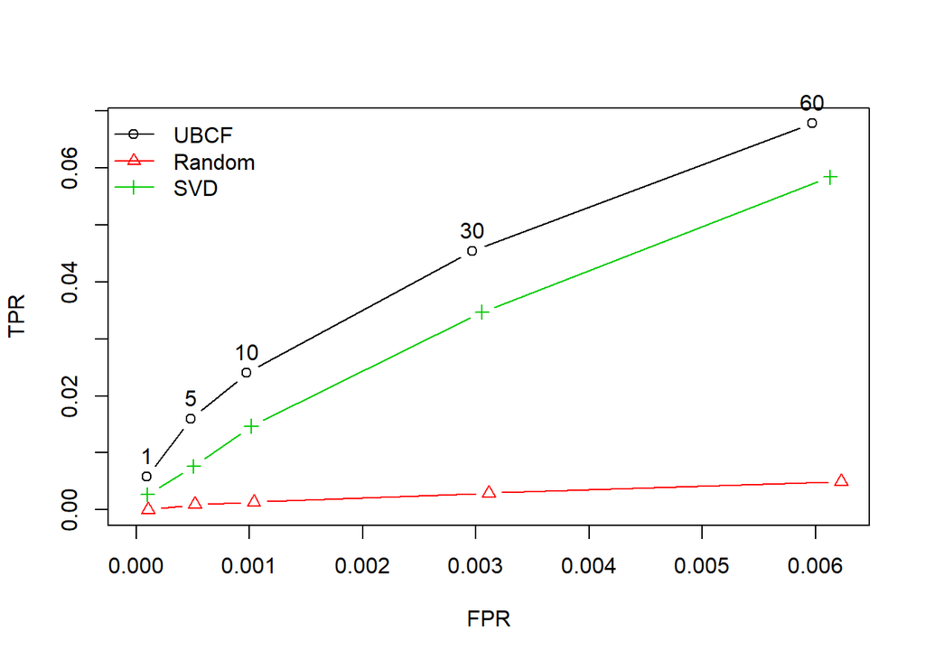

```r
# ROC Curve
plot(evalResults,
     annotate = TRUE, legend = "topleft", main = "ROC Curve")
```

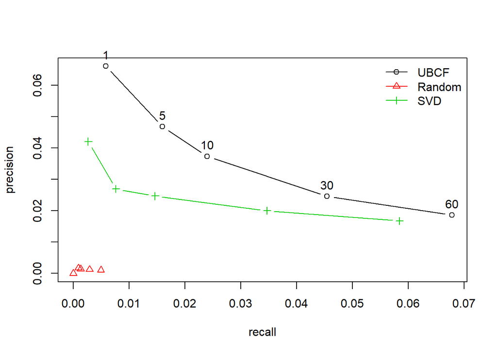

```r
# Precision-Recall Plot
plot(evalResults, "prec/rec",
     annotate = TRUE, legend = "topright", main = "Precision-Recall")
```

UBCF performs better than SVD and considerably better than the Random model.

• Now, Let us see the training and prediction time.

• From the table below we can see that the UBCF model can be created fairly quickly, but predicting results takes considerable time. The Random model is pretty efficient all around. The SVD model takes longer to build than to predict, but altogether it is quicker than the UBCF model.

```r
rownames(timing) <- timing$Model
knitr::kable(timing[, 2:3], format = "html") %>%
  kableExtra::kable_styling(bootstrap_options = c("striped", "hover"))
```

|  | Training | Predicting |
| --- | --- | --- |
| UBCF | 0.01 | 130.64 |
| RANDOM | 0.00 | 2.53 |
| SVD | 12.72 | 3.34 |

# Implement Support for Business/User Experiance Goal

• It may not always be desirable to recommend products that are likely to be most highly rated by a user. Recommending somewhat unexpected products may improve user experience, expand user preferences, provide additional knowledge about a user.

• In order to make sure that most of recommendations are still likely to be highly rated we only allow very minor influence of the Random model (0.99 vs. 0.01 weight between UBCF and Random models).

```r
model_Hybrid <- HybridRecommender(
    modelUBCF,
    modelRandom,
    weights = c(0.99, 0.01))
pred_Hybrid <- predict(model_Hybrid, newdata = known, type = "ratings")
( accHybrid <- calcPredictionAccuracy(pred_Hybrid, unknown) )
```

```
##      RMSE       MSE       MAE
## 1.4019483 1.9654589 0.9436949
```

**Comprison of the accuracy**

Let us look at top 10 recommendations for the first user in the test set.

```r
pUBCF <- predict(modelUBCF, newdata = known[1], type = "topNList")
pHybrid <- predict(model_Hybrid, newdata = known[1], type = "topNList")
```

```r
pUBCF@items
```

```
## $A103WXT3CHVY0H
##  [1] 2569   41  485 2870 2882   32 5148  435 2294 2914
```

```r
pHybrid@items
```

```
## $A103WXT3CHVY0H
##  [1] 2569  485   41 2870   32 2914 2294 2187 1743 6187
```

Now as we see, the Hybrid model includes most of the items recommended by the UBCF model, but there are new items and the order is different.

# Conclusion

• In this project we have build three different recommender system algorithms and compared the accuracy of all the three different models. Similar process can be employed to compare additional models or to adjust model parameters to find the most optimal model.

**Additional experiments that could be performed**

• One of the approaches in measuring success of diversification may be **A/B testing.** Users are randomly divided into two groups and each group is offered a slightly different experience. For instance, one group may get recommendations only from the UBCF model while the other group will get recommendations from the hybrid model.

• User experience is measured in some way. The least instrusive way is to monitor user interaction. In this example of Amazon products, a click on a recommendation suggested by the random element of the model will point to the fact that the hybrid model provides valuable recommendations.

• Of course, it is possible to track other metrics - products bought, time spent on product page, amount spent, etc. The basic idea is to see if the hybrid model provides meaningful improvement to the basic model.

• It is important to have objective measures when building and optimizing data science models. Evaluation of a model that returns highly relevant, but redundant recommendations should reflect that the model may score poorly in user experience.

• One of the approaches to measure diversity is described in [Novelty and Diversity in Information Retrieval Evaluation](https://plg.uwaterloo.ca/~gvcormac/novelty.pdf). This or similar measurement should be incorporated in projects of this type.